# Summary - Maths & Statistics

# 1 R Skills

## 1.1 Basics

### 1.1.1 Managing Packages

If a package is not yet installed in the current project on may call the function `install.package(“PackageName”)`. Afterwards the package needs to be included in the current document:

```r
library(ggplot2)
```

### 1.1.2 The Working Directory

The working directory is normaly set to the location of the project. It can be called by:

```r
getwd()
```

If required, the working directory can be changed to another path:

```r
setwd("/Users/folder1/folder11/R_Stuff")
```

### 1.1.3 Data Types

```r
typeof(5)
typeof("text")
typeof(TRUE)
```

```
## [1] "double"
## [1] "character"
## [1] "logical"
```

### 1.1.4 Arithmetic with R

```r
5 + 5 # An addition
5 - 4 # A subtraction
3 * 5 # A multiplication
9 / 3 # A division
2 ^ 5 # Exponentiation
7 %% 3 # Modulo
```

```
## [1] 10
## [1] 1
## [1] 15
## [1] 3
## [1] 32
## [1] 1
```

### 1.1.5 Object Assignment

```r
ob1 <- 5
ob2 <- 13
ob1 + ob2
```

```
## [1] 18
```

## 1.2 Loops

## 1.3 Declaring Functions

## 1.4 Lists

### 1.4.1 Creating a List

### 1.4.2 Getting data from a List

### 1.4.3 Appeding to a List

### 1.4.4 Subsetting a List

### 1.4.5 lapply, sapply and vapply

## 1.5 Data Frames

## 1.6 Importing Data

## 1.7 ggplot2

## 1.8 Regular Expressions

## 1.9 Handeling Dates

# 2 Mathematics and Statistics

## 2.1 Algebra

### 2.1.1 Vectors

#### 2.1.1.1 Creating a vector

```r
v1 <- c(1, 2, 3, 4, 5)
v1
length(v1)
```

```
## [1] 1 2 3 4 5
## [1] 5
```

#### 2.1.1.2 Auto population of a vector

```r
c(rep(0, times = 5))
c(rep(c(1, 2), times = 3))
c(5:9)
c(seq(from = 1, to = 7, by = 2))
c(seq(from = 1, to = 7, length = 5))
```

```
## [1] 0 0 0 0 0
## [1] 1 2 1 2 1 2
## [1] 5 6 7 8 9
## [1] 1 3 5 7
## [1] 1.0 2.5 4.0 5.5 7.0
```

#### 2.1.1.3 Arithmetic with vectors

```r
a <- 1:5
b <- 3:7
a+b
a-b
a*b
a/b
a^(b-a)
```

```
## [1]  4  6  8 10 12
## [1] -2 -2 -2 -2 -2
## [1]  3  8 15 24 35
## [1] 0.3333333 0.5000000 0.6000000 0.6666667 0.7142857
## [1]  1  4  9 16 25
```

```r
a%*%b
```

```
##      [,1]
## [1,]   85
```

### 2.1.2 Matrices

#### 2.1.2.1 Creating a matrix

```r
m1 <- matrix(c(1:6), ncol = 3, byrow = TRUE)
m1
```

```
##      [,1] [,2] [,3]
## [1,]    1    2    3
## [2,]    4    5    6
```

```r
diag(c(1:4))
```

```
##      [,1] [,2] [,3] [,4]
## [1,]    1    0    0    0
## [2,]    0    2    0    0
## [3,]    0    0    3    0
## [4,]    0    0    0    4
```

```r
diag(3)
```

```
##      [,1] [,2] [,3]
## [1,]    1    0    0
## [2,]    0    1    0
## [3,]    0    0    1
```

#### 2.1.2.2 Length, Dimensions and Slicing

```r
length(m1)
dim(m1)
```

```
## [1] 6
## [1] 2 3
```

```r
m1[2,3]
m1[,2]
```

```
## [1] 6
## [1] 2 5
```

#### 2.1.2.3 Arithmetic with matrices

```r
m2 <- matrix(c(1:6), ncol = 2, byrow = TRUE)
m1
m2
```

```
##      [,1] [,2] [,3]
## [1,]    1    2    3
## [2,]    4    5    6
##      [,1] [,2]
## [1,]    1    2
## [2,]    3    4
## [3,]    5    6
```

```r
3*m1 # scalar multiplication
```

```
##      [,1] [,2] [,3]
## [1,]    3    6    9
## [2,]   12   15   18
```

```r
m1%*%m2
```

```
##      [,1] [,2]
## [1,]   22   28
## [2,]   49   64
```

```r
m2%*%m1
```

```
##      [,1] [,2] [,3]
## [1,]    9   12   15
## [2,]   19   26   33
## [3,]   29   40   51
```

```r
m1*m2
```

```
## Error in m1 * m2: nicht passende Arrays
```

#### 2.1.2.4 Transpose matrices

Let ${\bf M1}=[a_{ij}]$ then ${\bf M1'}=[a_{ji}]$

```r
m1
```

```
##      [,1] [,2] [,3]
## [1,]    1    2    3
## [2,]    4    5    6
```

```r
t(m1)
```

```
##      [,1] [,2]
## [1,]    1    4
## [2,]    2    5
## [3,]    3    6
```

$({\bf M1'})'={\bf M1}$

```r
t(t(m1))
```

```
##      [,1] [,2] [,3]
## [1,]    1    2    3
## [2,]    4    5    6
```

${\bf M1}{\bf M1'}$ always yields a symmetric matrix ${\bf Q}$

```r
m1%*%t(m1)
```

```
##      [,1] [,2]
## [1,]   14   32
## [2,]   32   77
```

#### 2.1.2.5 Inverse of matrix

An $n \times n$ matrix ${\bf M}$ has an inverse, denoted ${\bf M^{-1}}$, provided that ${\bf M}{\bf M^{-1}}={\bf I_{n}}$

```r
m3 <- matrix(c(2, 5, 1, 3), nrow = 2, byrow = TRUE)
m3
```

```
##      [,1] [,2]
## [1,]    2    5
## [2,]    1    3
```

```r
solve(m3)
```

```
##      [,1] [,2]
## [1,]    3   -5
## [2,]   -1    2
```

```r
m3%*%solve(m3)
```

```
##      [,1] [,2]
## [1,]    1    0
## [2,]    0    1
```

Otherwise it is said to be noninvertible or singular:

```r
solve(matrix(c(1:9), nrow = 3))
```

```
## Error in solve.default(matrix(c(1:9), nrow = 3)): Lapackroutine dgesv: System ist genau singulär: U[3,3] = 0
```

#### 2.1.2.6 Rank of a matrix

```r
m4 <- matrix(c(1,2,3,2,4,6,10,20,30), ncol = 3, byrow = FALSE)
m4
```

```
##      [,1] [,2] [,3]
## [1,]    1    2   10
## [2,]    2    4   20
## [3,]    3    6   30
```

```r
qr(m4)$rank
```

```
## [1] 1
```

The rank of the matrix is 1, because $Col2 = 2*Col1$ and $Col3 = 10*Col1$. This attribute can be used to reduce the size of matrices and data.

#### 2.1.2.7 Eigenvalues

We use the example of a $3 \times 3$ matrix. This could be considered as the variance-covariance matrix of three variables, but the main thing is that the matrix is **square** and **symmetric**, which guarrantees that the eigenvalues $\lambda_{i}$ are real numbers.

```r
m5 <- matrix(c(13, -4, 2, -4, 11, -2, 2, -2, 8), ncol = 3, byrow = TRUE)
m5
```

```
##      [,1] [,2] [,3]
## [1,]   13   -4    2
## [2,]   -4   11   -2
## [3,]    2   -2    8
```

```r
eigen(m5)
```

```
## eigen() decomposition
## $values
## [1] 17  8  7
##
## $vectors
##            [,1]       [,2]      [,3]
## [1,]  0.7453560  0.6666667 0.0000000
## [2,] -0.5962848  0.6666667 0.4472136
## [3,]  0.2981424 -0.3333333 0.8944272
```

As shown above, this returns a namend list, containing the eigenvalues and eigenvectors. One may test the result by calculating the required equation for this eigenvalues:

$(A- \lambda I_{n})x=0$

```r
m_test1 = m5 - eigen(m5)$values[1] * diag(3)
m_test1
```

```
##      [,1] [,2] [,3]
## [1,]   -4   -4    2
## [2,]   -4   -6   -2
## [3,]    2   -2   -9
```

which leads to:

$det(A- \lambda I_{n})=0$

```r
round(det(m_test1), digits = 2)
```

```
## [1] 0
```

This should also be true for the second eigenvalue:

```r
m_test2 = m5 - eigen(m5)$values[2] * diag(3)
round(det(m_test2), digits = 2)
```

```
## [1] 0
```

### 2.1.3 Linear Algebra

Supose we have the following system of linear equations:

$\begin{alignedat}{7}3x&&\;+\;&&2y&&\;-\;&&z&&\;=\;&&1&\\2x&&\;-\;&&2y&&\;+\;&&4z&&\;=\;&&-2&\\-x&&\;+\;&&{\tfrac {1}{2}}y&&\;-\;&&z&&\;=\;&&0&\end{alignedat}$

This can be converted into one matrix and one vector:

```r
a = matrix(c(3, 2, -1, 2, -2, 4, -1, 0.5, -1), ncol = 3, byrow = TRUE)
a
```

```
##      [,1] [,2] [,3]
## [1,]    3  2.0   -1
## [2,]    2 -2.0    4
## [3,]   -1  0.5   -1
```

```r
b = c(1, -2, 0)
b
```

```
## [1]  1 -2  0
```

And solved using the **solve()** function:

```r
solve(a,b)
```

```
## [1]  1 -2 -2
```

## 2.2 Calculus

### 2.2.1 Functions

Constant function: $f(x)=a+b$ Linear function: $f(x)=ax+b$ Quadratic function: $f(x)=ax^{2}+b$ … In R these can be written as follows:

```r
x = 1:10
f_c = 3 + 1
f_l = 3*x + 1
f_q = 3*(x**2) + 1
```

One may plot the different functions:

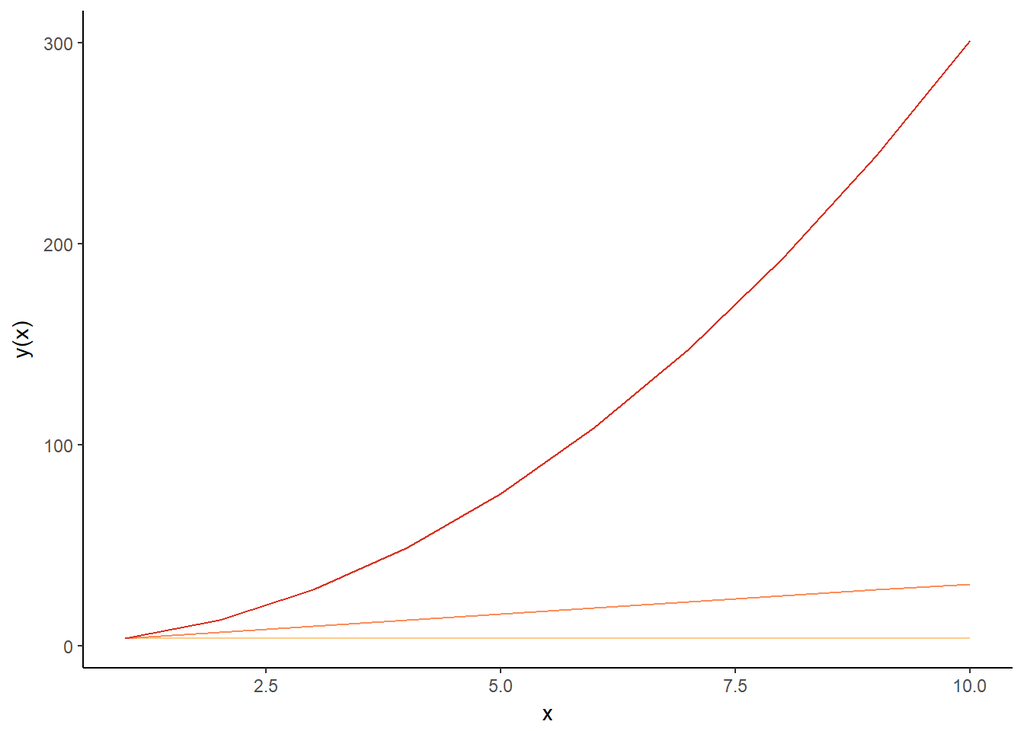

```r
data <- data.frame(x = x, f_c = f_c,
                   f_l = f_l, f_q = f_q)
ggplot(data, aes(x)) +
  geom_line(aes(y = f_c), color = "#fdcc8a") +
  geom_line(aes(y = f_l), color = "#fc8d59") +
  geom_line(aes(y = f_q), color = "#d7301f") +
  labs(y = "y(x)") +
  theme_classic()
```

### 2.2.2 Derivatives

#### 2.2.2.1 First and Second Derivative

- The first derivative $f'(x)$ describes the rate of change / slope of the tangent at $x$.
- The second derivative $f''(x)$ describes the change in the rate of change / curvature of the function near $x$.

Lets see what the first and second derivative of our quadratic equation $f(x)=3x^{2}+1$ are:

```r
D(expression(3*(x**2) + 1), "x")
```

```
## 3 * (2 * x)
```

```r
D(D(expression(3*(x**2) + 1), "x"), "x")
```

```
## 3 * 2
```

The function `D` only displays the derivative as plain text. To construct an actual function in R one has to use the function `deriv`

```r
deriv_f <- deriv(expression(3*(x**2) + 1), "x", function.arg = TRUE, hessian = TRUE)
deriv_f
```

```
## function (x)
## {
##     .value <- 3 * x^2 + 1
##     .grad <- array(0, c(length(.value), 1L), list(NULL, c("x")))
##     .hessian <- array(0, c(length(.value), 1L, 1L), list(NULL,
##         c("x"), c("x")))
##     .grad[, "x"] <- 3 * (2 * x)
##     .hessian[, "x", "x"] <- 3 * 2
##     attr(.value, "gradient") <- .grad
##     attr(.value, "hessian") <- .hessian
##     .value
## }
```

The first derivative can be found under the argument `.grad` and the second derivative under the argument `.hessian`. They can be accessed as follows:

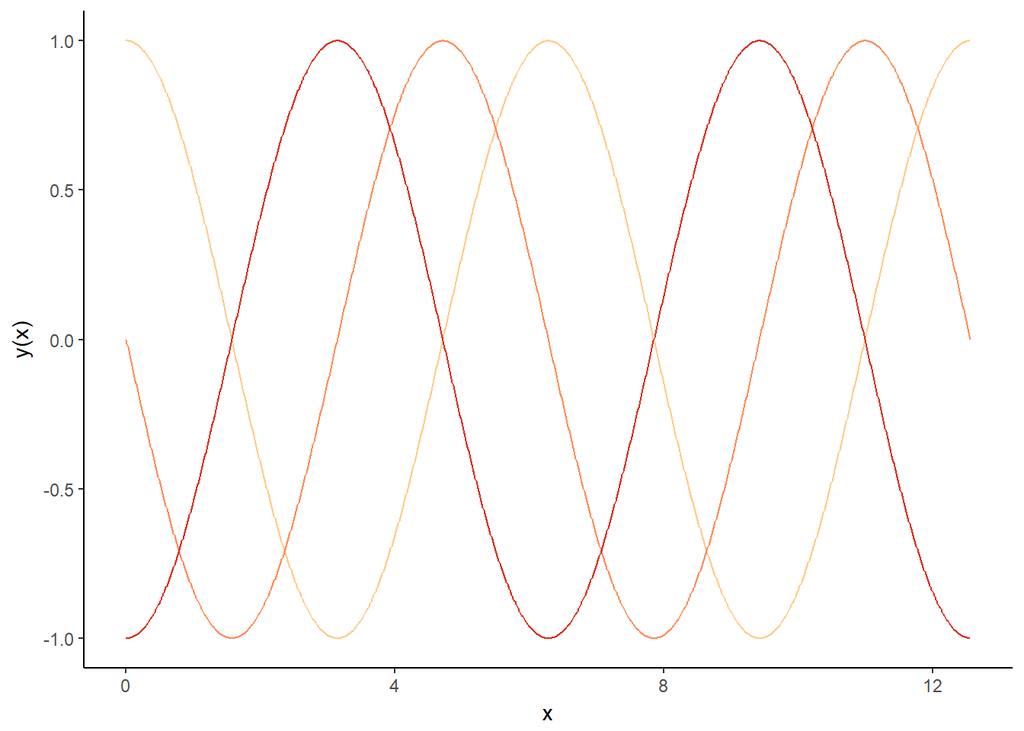

```r
x <- seq(from = 0, to = 4*pi, length = 1000)
cos <- cos(x)

deriv_cos = deriv(expression(cos(x)), "x", function.arg = TRUE, hessian = TRUE)

first_deriv <- as.numeric(attributes(deriv_cos(x))$gradient)
second_deriv <- as.numeric(attributes(deriv_cos(x))$hessian)

data <- data.frame(x_val = x, cos_val = cos, first_val = first_deriv, second_val = second_deriv)

ggplot(data = data, aes(x = x_val)) +
  geom_line(aes(y = cos_val), color = "#fdcc8a") +
  geom_line(aes(y = first_val), color = "#fc8d59") +
  geom_line(aes(y = second_val), color = "#d7301f") +
  labs(x = "x", y = "y(x)") +
  theme_classic()
```

#### 2.2.2.2 Partial derivatives and the hessian (Hesse-Matrix)

For functions with two or more independent variables there is also more than one first and second derivative. These derivatives are called the partial derivatives. When finding the partial derivative of one variable, all other variables can temporarilly be considered as constant. An examplary function may be:

$f(x,y) = 6x^{3}+4y^{2}$

The first partial derivatives are as follows:

```r
D(expression(6*x^3+4*y^2), "x")
```

```
## 6 * (3 * x^2)
```

```r
D(expression(6*x^3+4*y^2), "y")
```

```
## 4 * (2 * y)
```

For higher order partial derivatives there are $n^{r}$ derivatives, with $n$ being the number of independent variables and $r$ the order of the derivatives.

The second derivatives for a function with two independent variables can be summarized by using the hessian:

$H:=\begin{pmatrix}\left(\frac{\partial^2f}{\partial x\partial x}\right) & \left(\frac{\partial^2f}{\partial x\partial y}\right) \\ \left(\frac{\partial^2f}{\partial y\partial x}\right) & \left(\frac{\partial^2f}{\partial y\partial y}\right)\end{pmatrix}$

If the function is steady at every point $(x,y)$ the following is true $\frac{\partial^2f}{\partial x\partial y} = \frac{\partial^2f}{\partial y\partial x}$. This may also be observed, by using the `deriv` function again:

```r
deriv(expression(6*x^3+4*y^2), c("x", "y"), function.arg = TRUE, hessian = TRUE)
```

```
## function (x, y)
## {
##     .value <- 6 * x^3 + 4 * y^2
##     .grad <- array(0, c(length(.value), 2L), list(NULL, c("x",
##         "y")))
##     .hessian <- array(0, c(length(.value), 2L, 2L), list(NULL,
##         c("x", "y"), c("x", "y")))
##     .grad[, "x"] <- 6 * (3 * x^2)
##     .hessian[, "x", "x"] <- 6 * (3 * (2 * x))
##     .hessian[, "x", "y"] <- .hessian[, "y", "x"] <- 0
##     .grad[, "y"] <- 4 * (2 * y)
##     .hessian[, "y", "y"] <- 4 * 2
##     attr(.value, "gradient") <- .grad
##     attr(.value, "hessian") <- .hessian
##     .value
## }
```

### 2.2.3 Min and Max of a function

Building on what can be discovered, when evaluating the derivatives of a function the following can be stated. When $f'(x)=0$ then $f(x)$ is a critical point:

- if $f''(x)>0$ then $f(x)$ is a local minimum
- if $f''(x)<0$ then $f(x)$ is a local maximum

```r
x <- seq(from = pi/2, to = 5*pi/2, by = pi/16)
cos <- cos(x)

deriv_cos = deriv(expression(cos(x)), "x", function.arg = TRUE, hessian = TRUE)

first_deriv <- as.numeric(attributes(deriv_cos(x))$gradient)
second_deriv <- as.numeric(attributes(deriv_cos(x))$hessian)

x_point <- integer()
y_point <- integer()

for(i in x){
  val = round(as.numeric(attributes(deriv_cos(i))$gradient), 3)
  if ( val == 0 ) {

    if (as.numeric(attributes(deriv_cos(i))$hessian) > 0) {

      print(paste("Minimum at x =", round(i, 3), ", y =", cos(i)))
      x_point <- c(x_point, i)
      y_point <- c(y_point, cos(i))

    } else if (as.numeric(attributes(deriv_cos(i))$hessian) < 0) {

      print(paste("Maximum at x =", round(i, 3), ", y =", cos(i)))
      x_point <- c(x_point, i)
      y_point <- c(y_point, cos(i))

    }
  }
}
```

```
## [1] "Minimum at x = 3.142 , y = -1"
## [1] "Maximum at x = 6.283 , y = 1"
```

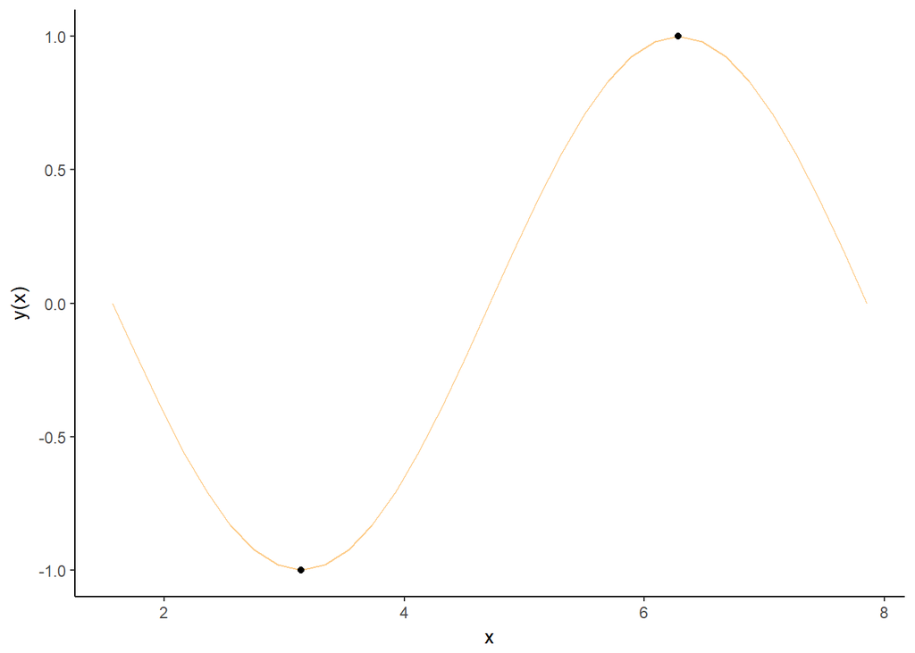

```r
data <- data.frame(x_val = x, cos_val = cos, first_val = first_deriv, second_val = second_deriv)
point_data = data.frame(x = x_point, y = y_point)

ggplot(data = data, aes(x = x_val)) +
  geom_line(aes(y = cos_val), color = "#fdcc8a") +
  labs(x = "x", y = "y(x)") +
  theme_classic() +
  geom_point(data = point_data, mapping = aes(x = x, y= y))
```